# Spanning Tree-based NNGP

Bora Jin

Spanning Tree-based Nearest Neighbor Gaussian Process (STNNGP) is a multivariate spatial regression model for large data.

### Model specifications

Let $q$ be the number of variables, $\mathscr{D} \subset \mathbb{R}^d$ be our domain of interest, and $\mathscr{S}=\{\mathbf{s}_1,\dots,\mathbf{s}_n\} \subset \mathscr{D}$ be an arbitrary set of locations. We assume a spanning tree $T$ among $q$ variables known, which defines an inter-variable relationship. A spanning tree is an undirected graph, but we can directly obtain a set of directed edges from the spanning tree by choosing a root and flowing away from the root. In following examples, we arbitrarily choose the first variable to be the root and have $E_T = \{(j \rightarrow k) : k=2,\dots,q\}$ as the set of directed edges from $T$. Since $T$ is a spanning tree, every node has only one incoming edge except the root which has no incoming edge. In some cases, an inter-variable relationship may be known up to a graph, not up to a tree. We then take the known graph’s directed minimum spanning tree as $T$ whose edge weights are proportional to the negative of absolute empirical correlation coefficients between variables. To guarantee existence of a spanning tree, any graphs in consideration should be connected.

For $nq$-vector $\mathbf{y}(\mathscr{S}) = (y_1(\mathscr{S})^T, \dots, y_q(\mathscr{S}))^T$, we define its joint density as $\tilde{f}(\mathbf{y}(\mathscr{S})) = \prod_{i=1}^n \tilde{f}_{N}(\mathbf{y}(\mathbf{s}_i))$, in which the conditional density $\tilde{f}_{N}$ for each location $\mathbf{s}_i \in \mathscr{S}$ is
$$\begin{align}
\tilde{f}_N(\mathbf{y}(\mathbf{s}_i)) = f(y_1(\mathbf{s}_i)\mid y_1(N_d(\mathbf{s}_i)))\times \prod_{(j \rightarrow k)\in E_{T}} f(y_k(\mathbf{s}_i)\mid y_k(N_d(\mathbf{s}_i)), y_j(\mathbf{s}_i), y_j(N(\mathbf{s}_i)))
\label{eq:jointden_si}
\end{align}$$
with some base density $f$ where $N_d(\mathbf{s}_i) \subset \{\mathbf{s}_1,\dots,\mathbf{s}_{i-1}\}$ and $N(\mathbf{s}_i) \subset \mathscr{S}\setminus \{\mathbf{s}_i\}$ are a directed and an undirected nearest neighbor set of $\mathbf{s}_i$ by Euclidean distance, respectively.

An STNNGP model assumes a latent variable $w(\cdot)$ to be
$$\mathbf{w}(\mathscr{S}) \sim N(0, \Sigma),$$
at observed locations $\mathscr{S}$ for a spatial covariance matrix $\Sigma$. Marginalizing over $\mathbf{w}$ we obtain
$$\mathbf{y}(\mathscr{S}) \sim N((I_q\otimes X)\mathbf{\beta}_L, \Sigma+diag(\tau_1^2,\dots,\tau_q^2)\otimes I_n),$$
, where $X$ is a $n\times p$ matrix of covariates, $\mathbf{\beta}_L = (\mathbf{\beta}_1^T, \dots, \mathbf{\beta}_q^T)^T$ is a $pq$-vector of coefficients, and $\Sigma+diag(\tau_1^2,\dots,\tau_q^2)\otimes I_n$ is the spatial covariance matrix with variable-specific nuggets.

The package `STNNGP` implements a separable and a nonseparable model; a separable model assumes $\Sigma = R \otimes M$ where $R$ is a $q\times q$ matrix of inter-variable correlation coefficients whose $(j,k)$ element is defined and has a value between -1 and 1 if $(j\rightarrow k) \in E_T$ or $(k\rightarrow j) \in E_T$. $M$ is an $n\times n$ Matern covariance matrix with spatial variability $\sigma^2$, decay $\phi$, and smoothness $\nu$. A nonseparable model assumes a multivariate Matern covariance function where each marginal Matern covariance has its own $(\sigma_j^2, \phi_j, \nu_j)$ for $j=1,\dots,q$. We define a cross-covariance function $C_{jk}(\mathbf{s},\mathbf{s}') = \rho_{jk}\sigma_j\sigma_k 2^{1-\nu_{jk}}(\phi_{jk} \|\mathbf{s}-\mathbf{s}'\|)^{\nu_{jk}}K_{\nu_{jk}}(\phi_{jk} \|\mathbf{s}-\mathbf{s}'\|)/\Gamma(\nu_{jk})$ if $(j\rightarrow k) \in E_T$ or $(k\rightarrow j) \in E_T$. Due to our spanning tree approach, we simply need to ensure validity of a bivariate Matern covariance for each $(j\rightarrow k) \in E_T$. We follow Theorem 3 (c) in [Gneiting, Kleiber, and Schlather (2010)](https://doi.org/10.1198/jasa.2010.tm09420) for conditions to be a valid bivariate Matern model.

### Package illustration

This document presents model fitting and results of STNNGP latent models using the package `STNNGP`. In order to fit STNNGP response model, one can simply use `method = "response"`. We start with loading necessary packages:

```r
library(tidyverse)
theme_set(theme_bw())
library(igraph)
# devtools::install_github("jinbora0720/STNNGP")
library(STNNGP)
```

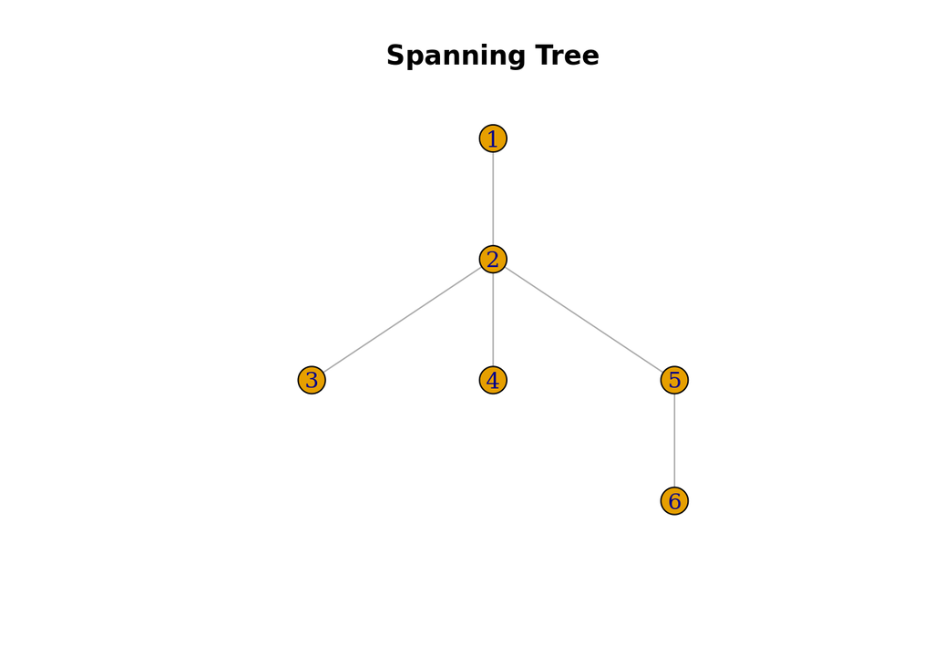

```r
# set seed
seed <- 20241107
set.seed(seed)

# create coordinates on a grid
coords <- expand.grid(seq(0, 1, length = 30),
                      seq(0, 1, length = 30)) %>%
  arrange(Var1) %>%
  as.matrix()
n <- nrow(coords)

# parameters
## number of neighbors
m <- 15

## covariance
q <- 6
tau.sq <- sample(seq(0.01, 0.05, length = q), replace = T)
rho <- runif(q-1, -1, 1)
sigma.sq <- 1
phi <- 3/0.8

## coefficients for covariates
p <- 2
beta <- matrix(runif(p*q, -1, 2), p, q)

## spanning tree
A <- matrix(0, q, q)
for (j in 2:q) {
  A[sample(j-1,1),j] <- 1
}
T0 <- graph_from_adjacency_matrix(A, "undirected")
plot(T0, layout = layout_as_tree(T0, root = 1), main = "Spanning Tree")
```

```r
# fitting parameters
verbose <- FALSE
n.threads <- 15
burn <- 1000
thin <- 2
save <- 1000
n.samples <- burn + thin*save
starting_latent <- list("beta" = beta, "phi" = phi, "sigma.sq" = sigma.sq,
                        "tau.sq" = tau.sq, "adjmat" = A, "rho" = rho)
tuning <- list("phi" = 0.1, "rho" = rep(0.07, q-1),
               "sigma.sq" = 0.01, "tau.sq" = tau.sq/10)
tuning_latent <- list("phi" = 0.1, "rho" = rep(0.06, q-1))                     # ~35% overall acceptance rate
priors <- list("phi.Unif" = c(3/1, 3/0.3), "sigma.sq.IG" = c(2, sigma.sq),
               "tau.sq.IG" = cbind(2, tau.sq))
cov.model <- "exponential"
```

```r
set.seed(seed)

# number of replicates
reps <- 5

# set seeds for replicates
seeds <- sample(100, reps)

# save results
betas <- matrix(0, reps, (p+1)*q)
betas_latent <- matrix(0, reps, p*q)
tau.sqs = tau.sqs_latent <- matrix(0, reps, q)
sigma.sqs = sigma.sqs_latent <- rep(0, reps)
phis = phis_latent <- rep(0, reps)
ssqphis = ssqphis_latent <- rep(0, reps)
rhos = rhos_latent <- matrix(0, reps, q-1)
mses_latent <- rep(0, reps)
telapsed = telapsed_latent <- rep(0, reps)

for (i in 1:reps) {
  seed <- seeds[i]
  data <- rstnngp(coords,
                  family = "gaussian",
                  mv.model = "separable",
                  params = list(tau.sq = tau.sq,
                                sigma.sq = sigma.sq,
                                phi = phi,
                                rho = rho,
                                beta = beta,
                                adjmat = A,
                                n.neighbors = m),
                  seed = seed)
  beta0 <- data$W %>% colMeans()
  starting <- list("beta" = rbind(beta0, beta), "phi" = phi, "sigma.sq" = sigma.sq,
                   "tau.sq" = tau.sq, "adjmat" = A, "rho" = rho)

  out <- STNNGP(Y ~ X,
                data = data,
                coords = coords,
                mv.model = "separable",
                method = "response",
                n.neighbors = m,
                starting = starting,
                tuning = tuning,
                priors = priors,
                cov.model = cov.model,
                n.samples = n.samples,
                n.omp.threads = n.threads,
                verbose = verbose)

  betas[i,] <- out$p.beta.samples[burn+thin*1:save,] %>% colMeans()
  tau.sqs[i,] <- out$p.tausq.samples[burn+thin*1:save,] %>% colMeans()
  sigma.sqs[i] <- out$p.theta.samples[burn+thin*1:save,1] %>% mean()
  phis[i] <- out$p.theta.samples[burn+thin*1:save,2] %>% mean()
  ssqphis[i] <- (out$p.theta.samples[burn+thin*1:save,1]*
                   out$p.theta.samples[burn+thin*1:save,2]) %>% mean()
  rhos[i,] <- out$p.rho.samples[burn+thin*1:save,] %>% colMeans()
  telapsed[i] <- out$run.time[3]

  out_latent <- STNNGP(Y ~ X-1,
                       data = data,
                       coords = coords,
                       mv.model = "separable",
                       method = "latent",
                       n.neighbors = m,
                       starting = starting_latent,
                       tuning = tuning_latent,
                       priors = priors,
                       cov.model = cov.model,
                       n.samples = n.samples,
                       n.omp.threads = n.threads,
                       verbose = verbose)

  betas_latent[i,] <- out_latent$p.beta.samples[burn+thin*1:save,] %>% colMeans()
  tau.sqs_latent[i,] <- out_latent$p.tausq.samples[burn+thin*1:save,] %>% colMeans()
  sigma.sqs_latent[i] <- out_latent$p.theta.samples[burn+thin*1:save,1] %>% mean()
  phis_latent[i] <- out_latent$p.theta.samples[burn+thin*1:save,2] %>% mean()
  ssqphis_latent[i] <- (out_latent$p.theta.samples[burn+thin*1:save,1]*
                   out_latent$p.theta.samples[burn+thin*1:save,2]) %>% mean()
  rhos_latent[i,] <- out_latent$p.rho.samples[burn+thin*1:save,] %>% colMeans()
  what <- out_latent$p.w.samples[,burn+thin*1:save] %>% rowMeans() %>% matrix(., n, q)
  mses_latent[i] <- mean(c(data$W - what)^2)
  telapsed_latent[i] <- out_latent$run.time[3]
}
```

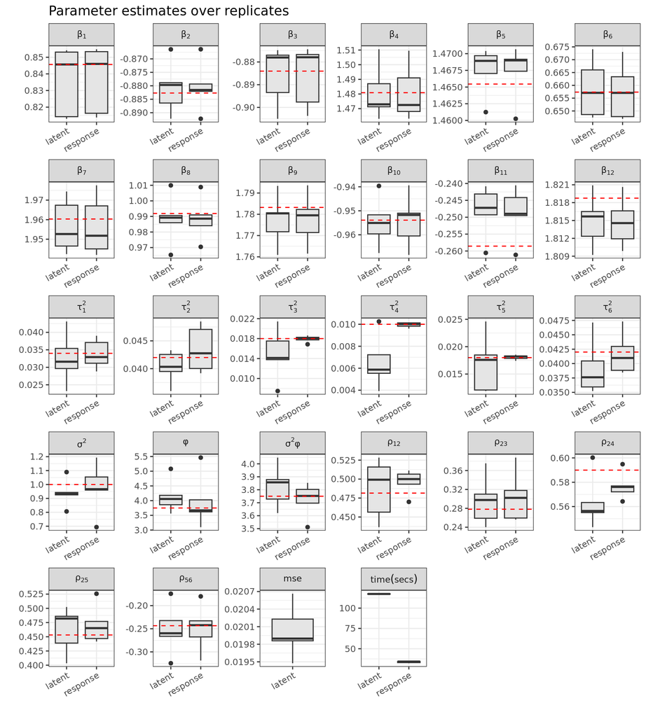

Here we observe that $\tau^2_j$’s tend to be slightly more accurately estimated with less standard errors in the response model where nuggets are updated via Metropolis than in the latent model where nuggets updated via Gibbs sampling. In this separable scenario, the latent model ($\sim$ 117.4 secs) takes 3.5 times longer than the response model ($\sim$ 33.7 secs).

Next, we examine a latent space from one of the replicates:

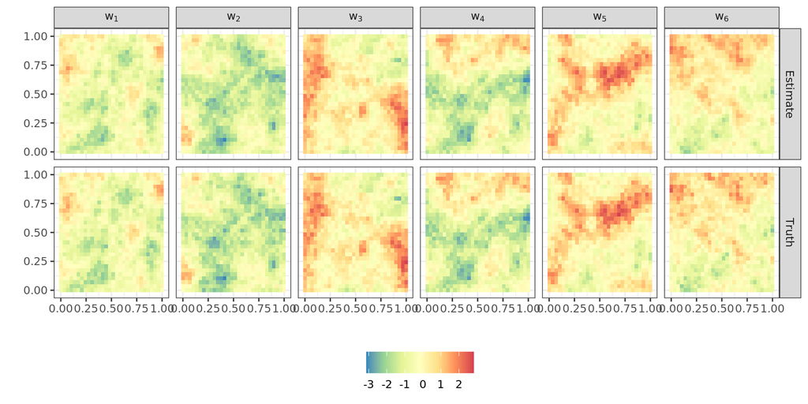

We also run a nonseparable STNNGP simulation.

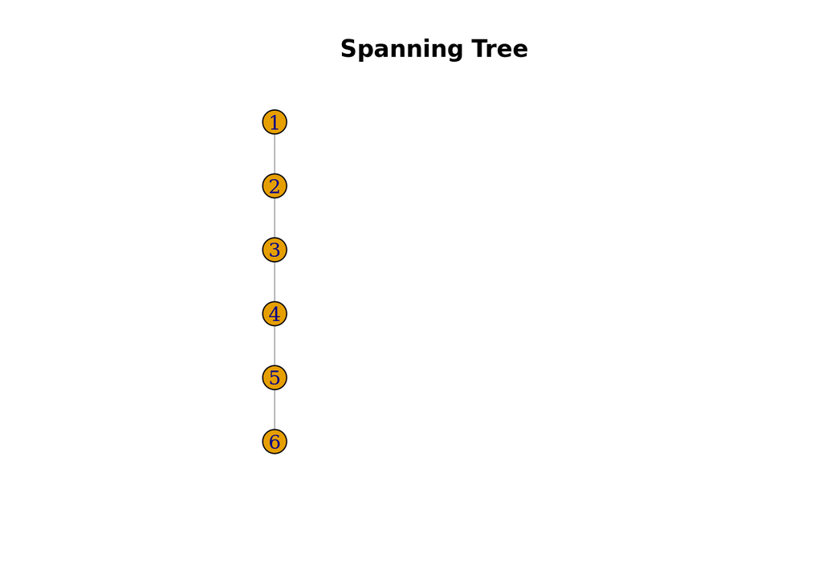

```r
# set seed
seed <- 20241107
set.seed(seed)

# create coordinates on a grid
coords <- expand.grid(seq(0, 1, length = 30),
                      seq(0, 1, length = 30)) %>%
  arrange(Var1) %>%
  as.matrix()
n <- nrow(coords)

# parameters
## number of neighbors
m <- 15

## spanning tree
q <- 6
A <- matrix(0, q, q)
for (j in 2:q) {
  A[j-1,j] <- 1
}
T0 <- graph_from_adjacency_matrix(A, "undirected")
plot(T0, layout = layout_as_tree(T0, root = 1), main = "Spanning Tree")
```

```r
## covariance
tau.sq <- seq(0.01, 0.05, length = q)
rho <- runif(q-1, -1, 1)
phi <- seq(3/0.2, 3/0.8, length = q)
sigma.sq <- seq(0.8, 1.5, length = q)
cross.phi <- rep(0, q-1)
for (me in 2:q) {
  parent <- which(A[,me] == 1)
  cross.phi[me-1] <- sqrt(0.5*(phi[parent]^2+phi[me]^2))
}

## coefficients for covariates
p <- 2
beta <- matrix(rnorm(p*q, sd = 3), p, q)

# fitting parameters
verbose <- FALSE
n.threads <- 15
burn <- 1000
thin <- 2
save <- 1000
n.samples <- burn + thin*save
starting_latent <- list("beta" = beta, "phi" = phi, "sigma.sq" = sigma.sq,
                        "tau.sq" = tau.sq, "adjmat" = A, "cross.phi" = cross.phi,
                        "rho" = rho)
tuning <- list("phi" = rep(0.05, q),
               "sigma.sq" = rep(0.01, q),
               "cross.phi" = rep(0.05, q-1),
               "rho" = rep(0.05, q-1),
               "tau.sq" = tau.sq/10)
tuning_latent <- list("phi" = rep(0.01, q),
                      "sigma.sq" = rep(0.02, q),
                      "cross.phi" = rep(0.01, q-1),
                      "rho" = rep(0.01, q-1))                                   # for ~35% acceptance rate
priors <- list("phi.Unif" = cbind(rep(3/1, q), rep(3/0.1, q)),
               "sigma.sq.IG" = cbind(2, sigma.sq),
               "tau.sq.IG" = cbind(2, tau.sq))
cov.model <- "exponential"
```

```r
set.seed(seed)

# number of replicates
reps <- 5

# set seeds for replicates
seeds <- sample(100, reps)

# save results
betas <- matrix(0, reps, (p+1)*q)
betas_latent <- matrix(0, reps, p*q)
tau.sqs = tau.sqs_latent <- matrix(0, reps, q)
sigma.sqs = sigma.sqs_latent <- matrix(0, reps, q)
phis = phis_latent <- matrix(0, reps, q)
ssqphis = ssqphis_latent <- matrix(0, reps, q)
cross.phis = cross.phis_latent <- matrix(0, reps, q-1)
rhos = rhos_latent <- matrix(0, reps, q-1)
mses_latent <- rep(0, reps)
telapsed_ns = telapsed_ns_latent <- rep(0, reps)

for (i in 1:reps) {
  seed <- seeds[i]
  data <- rstnngp(coords,
                  mv.model = "nonseparable",
                  params = list(tau.sq = tau.sq,
                                sigma.sq = sigma.sq,
                                phi = phi,
                                cross.phi = cross.phi,
                                rho = rho,
                                beta = beta,
                                adjmat = A,
                                n.neighbors = m),
                  seed = seed)
  beta0 <- data$W %>% colMeans()
  starting <- list("beta" = rbind(beta0, beta), "phi" = phi, "sigma.sq" = sigma.sq,
                   "tau.sq" = tau.sq, "adjmat" = A, "cross.phi" = cross.phi,
                   "rho" = rho)

  out <- STNNGP(Y ~ X,
                data = data,
                coords = coords,
                mv.model = "nonseparable",
                method = "response",
                n.neighbors = m,
                starting = starting, tuning = tuning, priors = priors,
                cov.model = cov.model,
                n.samples = n.samples,
                n.omp.threads = n.threads,
                verbose = verbose)

  betas[i,] <- out$p.beta.samples[burn+thin*1:save,] %>% colMeans()
  tau.sqs[i,] <- out$p.tausq.samples[burn+thin*1:save,] %>% colMeans()
  sigma.sqs[i,] <- out$p.sigmasq.samples[burn+thin*1:save,] %>% colMeans()
  phis[i,] <- out$p.phi.samples[burn+thin*1:save,] %>% colMeans()
  ssqphis[i,] <- (out$p.sigmasq.samples[burn+thin*1:save,]*
                   out$p.phi.samples[burn+thin*1:save,]) %>% colMeans()
  cross.phis[i,] <- out$p.crossphi.samples[burn+thin*1:save,] %>% colMeans()
  rhos[i,] <- out$p.rho.samples[burn+thin*1:save,] %>% colMeans()
  telapsed_ns[i] <- out$run.time[3]

  out_latent <- STNNGP(Y ~ X-1,
                       data = data,
                       coords = coords,
                       mv.model = "nonseparable",
                       method = "latent",
                       n.neighbors = m,
                       starting = starting_latent,
                       tuning = tuning_latent,
                       priors = priors,
                       cov.model = cov.model,
                       n.samples = n.samples,
                       n.omp.threads = n.threads,
                       verbose = verbose)

  betas_latent[i,] <- out_latent$p.beta.samples[burn+thin*1:save,] %>% colMeans()
  tau.sqs_latent[i,] <- out_latent$p.tausq.samples[burn+thin*1:save,] %>% colMeans()
  sigma.sqs_latent[i,] <- out_latent$p.sigmasq.samples[burn+thin*1:save,] %>% colMeans()
  phis_latent[i,] <- out_latent$p.phi.samples[burn+thin*1:save,] %>% colMeans()
  ssqphis_latent[i,] <- (out_latent$p.sigmasq.samples[burn+thin*1:save,]*
                           out_latent$p.phi.samples[burn+thin*1:save,]) %>% colMeans()
  cross.phis_latent[i,] <- out_latent$p.crossphi.samples[burn+thin*1:save,] %>% colMeans()
  rhos_latent[i,] <- out_latent$p.rho.samples[burn+thin*1:save,] %>% colMeans()
  what <- out_latent$p.w.samples[,burn+thin*1:save] %>% rowMeans() %>% matrix(., n, q)
  mses_latent[i] <- mean(c(data$W - what)^2)
  telapsed_ns_latent[i] <- out_latent$run.time[3]
}
```

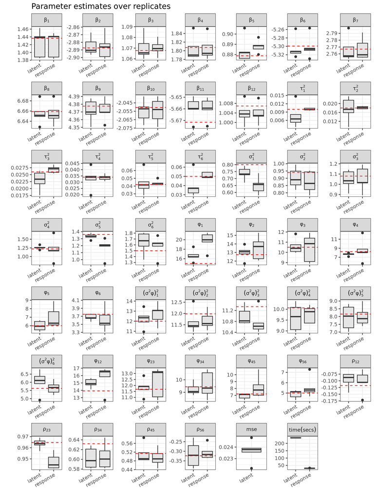

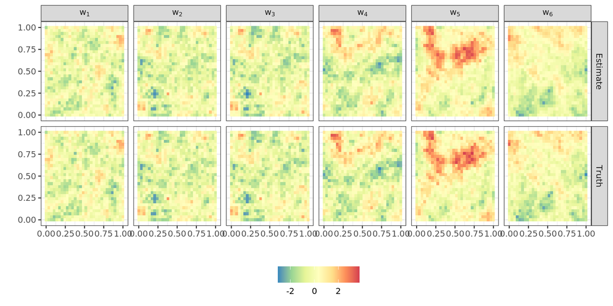

From the separable scenario to the nonseparable scenario, 15 more parameters were introduced, which is a 60% increase in the number of parameters from the separable model. Nonseparability led to -7.7% and 102.4% increase in computing time of the response model and latent model, respectively.